# Optimal Treatment Analysis

## Outcome Variable

**Outcome Variable:** whz

## Predictor Variables

**Intervention Variable:** mbmi

**Adjustment Set:**

- arm
- W_mage
- W_fage
- meducyrs
- feducyrs
- single
- brthmon
- delta_W_mage
- delta_W_fage
- delta_meducyrs
- delta_feducyrs
- delta_single
- delta_brthmon

## Stratifying Variables

The analysis was stratified on these variable(s):

- agecat
- studyid
- country

## Data Summary

| agecat | studyid | country | mbmi | n_cell | n |
| --- | --- | --- | --- | --- | --- |
| Birth | ki0047075b-MAL-ED | BANGLADESH | Normal weight | 205 | 233 |
| Birth | ki0047075b-MAL-ED | BANGLADESH | Underweight | 28 | 233 |
| Birth | ki0047075b-MAL-ED | BRAZIL | Normal weight | 167 | 176 |
| Birth | ki0047075b-MAL-ED | BRAZIL | Underweight | 9 | 176 |
| Birth | ki0047075b-MAL-ED | INDIA | Normal weight | 157 | 195 |
| Birth | ki0047075b-MAL-ED | INDIA | Underweight | 38 | 195 |
| Birth | ki0047075b-MAL-ED | NEPAL | Normal weight | 167 | 167 |
| Birth | ki0047075b-MAL-ED | NEPAL | Underweight | 0 | 167 |
| Birth | ki0047075b-MAL-ED | PERU | Normal weight | 264 | 269 |
| Birth | ki0047075b-MAL-ED | PERU | Underweight | 5 | 269 |
| Birth | ki0047075b-MAL-ED | SOUTH AFRICA | Normal weight | 221 | 226 |
| Birth | ki0047075b-MAL-ED | SOUTH AFRICA | Underweight | 5 | 226 |
| Birth | ki0047075b-MAL-ED | TANZANIA, UNITED REPUBLIC OF | Normal weight | 109 | 116 |
| Birth | ki0047075b-MAL-ED | TANZANIA, UNITED REPUBLIC OF | Underweight | 7 | 116 |
| Birth | ki1000304b-SAS-CompFeed | INDIA | Normal weight | 77 | 110 |
| Birth | ki1000304b-SAS-CompFeed | INDIA | Underweight | 33 | 110 |
| Birth | ki1017093-NIH-Birth | BANGLADESH | Normal weight | 23 | 28 |
| Birth | ki1017093-NIH-Birth | BANGLADESH | Underweight | 5 | 28 |
| Birth | ki1017093c-NIH-Crypto | BANGLADESH | Normal weight | 17 | 23 |
| Birth | ki1017093c-NIH-Crypto | BANGLADESH | Underweight | 6 | 23 |
| Birth | ki1119695-PROBIT | BELARUS | Normal weight | 13143 | 13664 |
| Birth | ki1119695-PROBIT | BELARUS | Underweight | 521 | 13664 |
| Birth | ki1126311-ZVITAMBO | ZIMBABWE | Normal weight | 8573 | 9029 |
| Birth | ki1126311-ZVITAMBO | ZIMBABWE | Underweight | 456 | 9029 |
| 6 months | ki0047075b-MAL-ED | BANGLADESH | Normal weight | 209 | 241 |
| 6 months | ki0047075b-MAL-ED | BANGLADESH | Underweight | 32 | 241 |
| 6 months | ki0047075b-MAL-ED | BRAZIL | Normal weight | 199 | 208 |
| 6 months | ki0047075b-MAL-ED | BRAZIL | Underweight | 9 | 208 |
| 6 months | ki0047075b-MAL-ED | INDIA | Normal weight | 186 | 235 |
| 6 months | ki0047075b-MAL-ED | INDIA | Underweight | 49 | 235 |

[output cut: 52 more lines]

The following strata were considered:

- agecat: 24 months, studyid: ki0047075b-MAL-ED, country: BANGLADESH
- agecat: 24 months, studyid: ki0047075b-MAL-ED, country: BRAZIL
- agecat: 24 months, studyid: ki0047075b-MAL-ED, country: INDIA
- agecat: 24 months, studyid: ki0047075b-MAL-ED, country: NEPAL
- agecat: 24 months, studyid: ki0047075b-MAL-ED, country: PERU
- agecat: 24 months, studyid: ki0047075b-MAL-ED, country: SOUTH AFRICA
- agecat: 24 months, studyid: ki0047075b-MAL-ED, country: TANZANIA, UNITED REPUBLIC OF
- agecat: 24 months, studyid: ki1017093-NIH-Birth, country: BANGLADESH
- agecat: 24 months, studyid: ki1017093b-PROVIDE, country: BANGLADESH
- agecat: 24 months, studyid: ki1017093c-NIH-Crypto, country: BANGLADESH
- agecat: 24 months, studyid: ki1066203-TanzaniaChild2, country: TANZANIA, UNITED REPUBLIC OF
- agecat: 24 months, studyid: ki1119695-PROBIT, country: BELARUS
- agecat: 24 months, studyid: ki1126311-ZVITAMBO, country: ZIMBABWE
- agecat: 24 months, studyid: ki1148112-LCNI-5, country: MALAWI
- agecat: 6 months, studyid: ki0047075b-MAL-ED, country: BANGLADESH
- agecat: 6 months, studyid: ki0047075b-MAL-ED, country: BRAZIL
- agecat: 6 months, studyid: ki0047075b-MAL-ED, country: INDIA
- agecat: 6 months, studyid: ki0047075b-MAL-ED, country: NEPAL
- agecat: 6 months, studyid: ki0047075b-MAL-ED, country: PERU
- agecat: 6 months, studyid: ki0047075b-MAL-ED, country: SOUTH AFRICA
- agecat: 6 months, studyid: ki0047075b-MAL-ED, country: TANZANIA, UNITED REPUBLIC OF
- agecat: 6 months, studyid: ki1000304b-SAS-CompFeed, country: INDIA
- agecat: 6 months, studyid: ki1017093-NIH-Birth, country: BANGLADESH
- agecat: 6 months, studyid: ki1017093b-PROVIDE, country: BANGLADESH
- agecat: 6 months, studyid: ki1017093c-NIH-Crypto, country: BANGLADESH
- agecat: 6 months, studyid: ki1066203-TanzaniaChild2, country: TANZANIA, UNITED REPUBLIC OF
- agecat: 6 months, studyid: ki1119695-PROBIT, country: BELARUS
- agecat: 6 months, studyid: ki1126311-ZVITAMBO, country: ZIMBABWE
- agecat: 6 months, studyid: ki1148112-LCNI-5, country: MALAWI
- agecat: Birth, studyid: ki0047075b-MAL-ED, country: BANGLADESH
- agecat: Birth, studyid: ki0047075b-MAL-ED, country: BRAZIL
- agecat: Birth, studyid: ki0047075b-MAL-ED, country: INDIA
- agecat: Birth, studyid: ki0047075b-MAL-ED, country: NEPAL
- agecat: Birth, studyid: ki0047075b-MAL-ED, country: PERU
- agecat: Birth, studyid: ki0047075b-MAL-ED, country: SOUTH AFRICA
- agecat: Birth, studyid: ki0047075b-MAL-ED, country: TANZANIA, UNITED REPUBLIC OF
- agecat: Birth, studyid: ki1000304b-SAS-CompFeed, country: INDIA
- agecat: Birth, studyid: ki1017093-NIH-Birth, country: BANGLADESH
- agecat: Birth, studyid: ki1017093c-NIH-Crypto, country: BANGLADESH
- agecat: Birth, studyid: ki1119695-PROBIT, country: BELARUS
- agecat: Birth, studyid: ki1126311-ZVITAMBO, country: ZIMBABWE

### Dropped Strata

Some strata were dropped due to rare outcomes:

- agecat: Birth, studyid: ki0047075b-MAL-ED, country: NEPAL
- agecat: 6 months, studyid: ki0047075b-MAL-ED, country: NEPAL
- agecat: 24 months, studyid: ki0047075b-MAL-ED, country: NEPAL
- agecat: 24 months, studyid: ki0047075b-MAL-ED, country: PERU
- agecat: 24 months, studyid: ki1066203-TanzaniaChild2, country: TANZANIA, UNITED REPUBLIC OF

## Methods Detail

We’re interested in the causal parameters $E[Y_a]$ for all values of $a \in \mathcal{A}$. These parameters represent the mean outcome if, possibly contrary to fact, we intervened to set all units to have $A=a$. Under the randomization and positivity assumptions, these are identified by the statistical parameters $\psi_a=E_W[E_{Y|A,W}(Y|A=a,W)]$. In addition, we’re interested in the mean of $Y$, $E[Y]$ under no intervention (the observed mean). We will estimate these parameters by using SuperLearner to fit the relevant likelihood factors – $E_{Y|A,W}(Y|A=a,W)$ and $p(A=a|W)$, and then updating our likelihood fit using a joint TMLE.

For unadjusted analyses ($W=\{\}$), initial likelihoods were estimated using Lrnr_glm to estimate the simple $E(Y|A)$ and Lrnr_mean to estimate $p(A)$. For adjusted analyses, a small library containing Lrnr_glmnet, Lrnr_xgboost, and Lrnr_mean was used.

Having estimated these parameters, we will then use the delta method to estimate relative risks and attributable risks relative to a prespecified baseline level of $A$.

# Results Detail

## Results Plots

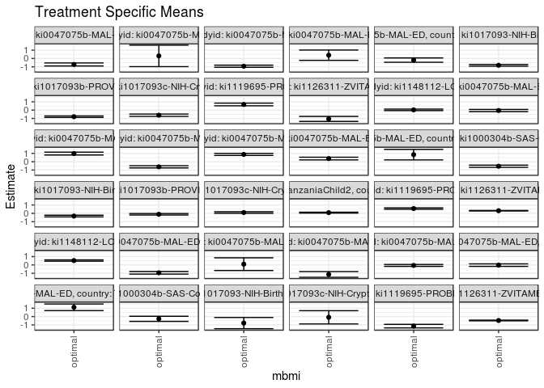

## Results Table

### Parameter: TSM

| agecat | studyid | country | intervention_level | baseline_level | estimate | ci_lower | ci_upper |
| --- | --- | --- | --- | --- | --- | --- | --- |
| Birth | ki0047075b-MAL-ED | BANGLADESH | optimal | observed | -0.9405909 | -1.0982698 | -0.7829119 |
| Birth | ki0047075b-MAL-ED | BRAZIL | optimal | observed | 0.0951922 | -0.6667195 | 0.8571038 |
| Birth | ki0047075b-MAL-ED | INDIA | optimal | observed | -1.1357464 | -1.4768621 | -0.7946307 |
| Birth | ki0047075b-MAL-ED | PERU | optimal | observed | -0.0544064 | -0.1690329 | 0.0602201 |
| Birth | ki0047075b-MAL-ED | SOUTH AFRICA | optimal | observed | -0.0179825 | -0.1686879 | 0.1327229 |
| Birth | ki0047075b-MAL-ED | TANZANIA, UNITED REPUBLIC OF | optimal | observed | 1.1125275 | 0.7165340 | 1.5085210 |
| Birth | ki1000304b-SAS-CompFeed | INDIA | optimal | observed | -0.2703469 | -0.5770181 | 0.0363243 |
| Birth | ki1017093-NIH-Birth | BANGLADESH | optimal | observed | -0.7816095 | -1.4526904 | -0.1105285 |
| Birth | ki1017093c-NIH-Crypto | BANGLADESH | optimal | observed | -0.0895082 | -0.8851916 | 0.7061752 |
| Birth | ki1119695-PROBIT | BELARUS | optimal | observed | -1.1443603 | -1.3560095 | -0.9327111 |
| Birth | ki1126311-ZVITAMBO | ZIMBABWE | optimal | observed | -0.4699464 | -0.5117298 | -0.4281630 |
| 6 months | ki0047075b-MAL-ED | BANGLADESH | optimal | observed | -0.0510942 | -0.1814154 | 0.0792271 |
| 6 months | ki0047075b-MAL-ED | BRAZIL | optimal | observed | 0.9765678 | 0.8079871 | 1.1451484 |
| 6 months | ki0047075b-MAL-ED | INDIA | optimal | observed | -0.6130726 | -0.7434510 | -0.4826943 |
| 6 months | ki0047075b-MAL-ED | PERU | optimal | observed | 0.8765153 | 0.7531167 | 0.9999139 |
| 6 months | ki0047075b-MAL-ED | SOUTH AFRICA | optimal | observed | 0.3773053 | 0.2167173 | 0.5378933 |
| 6 months | ki0047075b-MAL-ED | TANZANIA, UNITED REPUBLIC OF | optimal | observed | 0.8483491 | 0.2173947 | 1.4793034 |
| 6 months | ki1000304b-SAS-CompFeed | INDIA | optimal | observed | -0.5438225 | -0.6770585 | -0.4105864 |
| 6 months | ki1017093-NIH-Birth | BANGLADESH | optimal | observed | -0.3260778 | -0.4240175 | -0.2281380 |
| 6 months | ki1017093b-PROVIDE | BANGLADESH | optimal | observed | -0.1132662 | -0.2050951 | -0.0214373 |
| 6 months | ki1017093c-NIH-Crypto | BANGLADESH | optimal | observed | 0.0968366 | 0.0006832 | 0.1929900 |
| 6 months | ki1066203-TanzaniaChild2 | TANZANIA, UNITED REPUBLIC OF | optimal | observed | 0.0851446 | 0.0306063 | 0.1396829 |
| 6 months | ki1119695-PROBIT | BELARUS | optimal | observed | 0.5730923 | 0.4862973 | 0.6598874 |
| 6 months | ki1126311-ZVITAMBO | ZIMBABWE | optimal | observed | 0.3139192 | 0.2853648 | 0.3424736 |
| 6 months | ki1148112-LCNI-5 | MALAWI | optimal | observed | 0.5290580 | 0.4505878 | 0.6075283 |
| 24 months | ki0047075b-MAL-ED | BANGLADESH | optimal | observed | -0.7168034 | -0.8969515 | -0.5366552 |
| 24 months | ki0047075b-MAL-ED | BRAZIL | optimal | observed | 0.3076049 | -0.9800102 | 1.5952199 |
| 24 months | ki0047075b-MAL-ED | INDIA | optimal | observed | -0.9289175 | -1.0575318 | -0.8003032 |
| 24 months | ki0047075b-MAL-ED | SOUTH AFRICA | optimal | observed | 0.3927316 | -0.2250187 | 1.0104819 |
| 24 months | ki0047075b-MAL-ED | TANZANIA, UNITED REPUBLIC OF | optimal | observed | -0.1940661 | -0.4539297 | 0.0657975 |
| 24 months | ki1017093-NIH-Birth | BANGLADESH | optimal | observed | -0.8153230 | -0.9183000 | -0.7123461 |
| 24 months | ki1017093b-PROVIDE | BANGLADESH | optimal | observed | -0.7929163 | -0.8827616 | -0.7030711 |
| 24 months | ki1017093c-NIH-Crypto | BANGLADESH | optimal | observed | -0.6145703 | -0.7528091 | -0.4763314 |
| 24 months | ki1119695-PROBIT | BELARUS | optimal | observed | 0.6760536 | 0.5155426 | 0.8365646 |
| 24 months | ki1126311-ZVITAMBO | ZIMBABWE | optimal | observed | -1.0556279 | -1.3563317 | -0.7549241 |
| 24 months | ki1148112-LCNI-5 | MALAWI | optimal | observed | 0.0279236 | -0.0620050 | 0.1178523 |

### Parameter: E(Y)

| agecat | studyid | country | intervention_level | baseline_level | estimate | ci_lower | ci_upper |
| --- | --- | --- | --- | --- | --- | --- | --- |
| Birth | ki0047075b-MAL-ED | BANGLADESH | observed | observed | -0.9724464 | -1.1091046 | -0.8357881 |
| Birth | ki0047075b-MAL-ED | BRAZIL | observed | observed | 0.3832386 | 0.2044597 | 0.5620175 |
| Birth | ki0047075b-MAL-ED | INDIA | observed | observed | -1.0698974 | -1.2115847 | -0.9282102 |
| Birth | ki0047075b-MAL-ED | PERU | observed | observed | -0.0660967 | -0.1789362 | 0.0467429 |
| Birth | ki0047075b-MAL-ED | SOUTH AFRICA | observed | observed | -0.0346018 | -0.1831486 | 0.1139451 |
| Birth | ki0047075b-MAL-ED | TANZANIA, UNITED REPUBLIC OF | observed | observed | 0.7950000 | 0.5947353 | 0.9952647 |
| Birth | ki1000304b-SAS-CompFeed | INDIA | observed | observed | -0.1601818 | -0.3763991 | 0.0560355 |
| Birth | ki1017093-NIH-Birth | BANGLADESH | observed | observed | -1.4239286 | -1.7688028 | -1.0790544 |
| Birth | ki1017093c-NIH-Crypto | BANGLADESH | observed | observed | -0.7508696 | -1.2358912 | -0.2658480 |
| Birth | ki1119695-PROBIT | BELARUS | observed | observed | -1.1441269 | -1.3547476 | -0.9335062 |
| Birth | ki1126311-ZVITAMBO | ZIMBABWE | observed | observed | -0.4900343 | -0.5209436 | -0.4591251 |
| 6 months | ki0047075b-MAL-ED | BANGLADESH | observed | observed | -0.1397960 | -0.2688682 | -0.0107238 |
| 6 months | ki0047075b-MAL-ED | BRAZIL | observed | observed | 0.9644952 | 0.7999744 | 1.1290160 |
| 6 months | ki0047075b-MAL-ED | INDIA | observed | observed | -0.6987943 | -0.8241325 | -0.5734561 |
| 6 months | ki0047075b-MAL-ED | PERU | observed | observed | 1.0563787 | 0.9342938 | 1.1784635 |
| 6 months | ki0047075b-MAL-ED | SOUTH AFRICA | observed | observed | 0.5290428 | 0.3750394 | 0.6830463 |
| 6 months | ki0047075b-MAL-ED | TANZANIA, UNITED REPUBLIC OF | observed | observed | 0.5170513 | 0.3872178 | 0.6468847 |
| 6 months | ki1000304b-SAS-CompFeed | INDIA | observed | observed | -0.6441020 | -0.7710827 | -0.5171213 |
| 6 months | ki1017093-NIH-Birth | BANGLADESH | observed | observed | -0.4389101 | -0.5279432 | -0.3498771 |
| 6 months | ki1017093b-PROVIDE | BANGLADESH | observed | observed | -0.2079891 | -0.2925599 | -0.1234183 |
| 6 months | ki1017093c-NIH-Crypto | BANGLADESH | observed | observed | 0.0297622 | -0.0491685 | 0.1086930 |
| 6 months | ki1066203-TanzaniaChild2 | TANZANIA, UNITED REPUBLIC OF | observed | observed | 0.0775172 | 0.0241750 | 0.1308595 |
| 6 months | ki1119695-PROBIT | BELARUS | observed | observed | 0.5829956 | 0.5247249 | 0.6412663 |
| 6 months | ki1126311-ZVITAMBO | ZIMBABWE | observed | observed | 0.2928094 | 0.2648167 | 0.3208020 |
| 6 months | ki1148112-LCNI-5 | MALAWI | observed | observed | 0.4515431 | 0.3802415 | 0.5228446 |
| 24 months | ki0047075b-MAL-ED | BANGLADESH | observed | observed | -0.8208255 | -0.9429246 | -0.6987264 |
| 24 months | ki0047075b-MAL-ED | BRAZIL | observed | observed | 0.4282738 | 0.2252365 | 0.6313111 |
| 24 months | ki0047075b-MAL-ED | INDIA | observed | observed | -0.9525664 | -1.0684455 | -0.8366872 |
| 24 months | ki0047075b-MAL-ED | SOUTH AFRICA | observed | observed | 0.4096154 | 0.2902946 | 0.5289362 |
| 24 months | ki0047075b-MAL-ED | TANZANIA, UNITED REPUBLIC OF | observed | observed | 0.0500935 | -0.0748234 | 0.1750103 |
| 24 months | ki1017093-NIH-Birth | BANGLADESH | observed | observed | -0.9115790 | -1.0095022 | -0.8136559 |
| 24 months | ki1017093b-PROVIDE | BANGLADESH | observed | observed | -0.8864991 | -0.9695215 | -0.8034768 |
| 24 months | ki1017093c-NIH-Crypto | BANGLADESH | observed | observed | -0.6103502 | -0.7050157 | -0.5156847 |
| 24 months | ki1119695-PROBIT | BELARUS | observed | observed | 0.6869754 | 0.5725638 | 0.8013869 |
| 24 months | ki1126311-ZVITAMBO | ZIMBABWE | observed | observed | -1.1810028 | -1.2914599 | -1.0705456 |
| 24 months | ki1148112-LCNI-5 | MALAWI | observed | observed | -0.0469519 | -0.1290932 | 0.0351895 |

### Parameter: PAR

| agecat | studyid | country | intervention_level | baseline_level | estimate | ci_lower | ci_upper |
| --- | --- | --- | --- | --- | --- | --- | --- |
| Birth | ki0047075b-MAL-ED | BANGLADESH | optimal | observed | -0.0318555 | -0.1299961 | 0.0662851 |
| Birth | ki0047075b-MAL-ED | BRAZIL | optimal | observed | 0.2880465 | -0.4532735 | 1.0293665 |
| Birth | ki0047075b-MAL-ED | INDIA | optimal | observed | 0.0658490 | -0.2210225 | 0.3527205 |
| Birth | ki0047075b-MAL-ED | PERU | optimal | observed | -0.0116902 | -0.0277449 | 0.0043644 |
| Birth | ki0047075b-MAL-ED | SOUTH AFRICA | optimal | observed | -0.0166192 | -0.0387987 | 0.0055602 |
| Birth | ki0047075b-MAL-ED | TANZANIA, UNITED REPUBLIC OF | optimal | observed | -0.3175275 | -0.7439674 | 0.1089124 |
| Birth | ki1000304b-SAS-CompFeed | INDIA | optimal | observed | 0.1101651 | -0.0754877 | 0.2958178 |
| Birth | ki1017093-NIH-Birth | BANGLADESH | optimal | observed | -0.6423191 | -1.3120344 | 0.0273963 |
| Birth | ki1017093c-NIH-Crypto | BANGLADESH | optimal | observed | -0.6613614 | -1.4505390 | 0.1278163 |
| Birth | ki1119695-PROBIT | BELARUS | optimal | observed | 0.0002334 | -0.0079695 | 0.0084364 |
| Birth | ki1126311-ZVITAMBO | ZIMBABWE | optimal | observed | -0.0200879 | -0.0479676 | 0.0077917 |
| 6 months | ki0047075b-MAL-ED | BANGLADESH | optimal | observed | -0.0887018 | -0.1582302 | -0.0191734 |
| 6 months | ki0047075b-MAL-ED | BRAZIL | optimal | observed | -0.0120726 | -0.0461234 | 0.0219783 |
| 6 months | ki0047075b-MAL-ED | INDIA | optimal | observed | -0.0857217 | -0.1629058 | -0.0085376 |
| 6 months | ki0047075b-MAL-ED | PERU | optimal | observed | 0.1798634 | 0.1098101 | 0.2499166 |
| 6 months | ki0047075b-MAL-ED | SOUTH AFRICA | optimal | observed | 0.1517375 | 0.0729097 | 0.2305653 |
| 6 months | ki0047075b-MAL-ED | TANZANIA, UNITED REPUBLIC OF | optimal | observed | -0.3312978 | -0.9448137 | 0.2822181 |
| 6 months | ki1000304b-SAS-CompFeed | INDIA | optimal | observed | -0.1002796 | -0.1316405 | -0.0689187 |
| 6 months | ki1017093-NIH-Birth | BANGLADESH | optimal | observed | -0.1128323 | -0.1665188 | -0.0591459 |
| 6 months | ki1017093b-PROVIDE | BANGLADESH | optimal | observed | -0.0947229 | -0.1361366 | -0.0533091 |
| 6 months | ki1017093c-NIH-Crypto | BANGLADESH | optimal | observed | -0.0670744 | -0.1212321 | -0.0129167 |
| 6 months | ki1066203-TanzaniaChild2 | TANZANIA, UNITED REPUBLIC OF | optimal | observed | -0.0076273 | -0.0138757 | -0.0013790 |
| 6 months | ki1119695-PROBIT | BELARUS | optimal | observed | 0.0099033 | -0.0459502 | 0.0657567 |
| 6 months | ki1126311-ZVITAMBO | ZIMBABWE | optimal | observed | -0.0211098 | -0.0283522 | -0.0138674 |
| 6 months | ki1148112-LCNI-5 | MALAWI | optimal | observed | -0.0775150 | -0.1114107 | -0.0436192 |
| 24 months | ki0047075b-MAL-ED | BANGLADESH | optimal | observed | -0.1040221 | -0.2380325 | 0.0299883 |
| 24 months | ki0047075b-MAL-ED | BRAZIL | optimal | observed | 0.1206689 | -1.1340940 | 1.3754319 |
| 24 months | ki0047075b-MAL-ED | INDIA | optimal | observed | -0.0236488 | -0.0985820 | 0.0512843 |
| 24 months | ki0047075b-MAL-ED | SOUTH AFRICA | optimal | observed | 0.0168838 | -0.5944167 | 0.6281842 |
| 24 months | ki0047075b-MAL-ED | TANZANIA, UNITED REPUBLIC OF | optimal | observed | 0.2441596 | 0.0149423 | 0.4733768 |
| 24 months | ki1017093-NIH-Birth | BANGLADESH | optimal | observed | -0.0962560 | -0.1503651 | -0.0421469 |
| 24 months | ki1017093b-PROVIDE | BANGLADESH | optimal | observed | -0.0935828 | -0.1355457 | -0.0516199 |
| 24 months | ki1017093c-NIH-Crypto | BANGLADESH | optimal | observed | 0.0042201 | -0.0879720 | 0.0964121 |
| 24 months | ki1119695-PROBIT | BELARUS | optimal | observed | 0.0109217 | -0.0760168 | 0.0978603 |
| 24 months | ki1126311-ZVITAMBO | ZIMBABWE | optimal | observed | -0.1253748 | -0.3989286 | 0.1481789 |
| 24 months | ki1148112-LCNI-5 | MALAWI | optimal | observed | -0.0748755 | -0.1136859 | -0.0360651 |